# Data 605 Homework Week-11

## —————————————————————————

### **Student Name :** Sachid Deshmukh

### **Date :** 04/02/2019

- > [GitHub Location for rmd file](https://github.com/mlforsachid/MSDSQ2Data605/blob/master/Week10/HW-10/SachidVijay.Deshmukh60.Rmd)
- > [RPubs location of published file](http://rpubs.com/sachid/Data605Week10HW)

## —————————————————————————

### One Factor Regression

**In this exercise we will fit a simple linear regression model which will fit car stopping distance as a function of speed. We will use built in car dataset in R for this exercise**

**Let’s preview the car data set**

```r
head(cars)
```

```
##   speed dist
## 1     4    2
## 2     4   10
## 3     7    4
## 4     7   22
## 5     8   16
## 6     9   10
```

**As we can see there are two columns in this data set. speed indicates a car speed and distance which indicates a car stopping distance**

### Univariate Analysis

**First find out the data distribution of speed and distance variables**

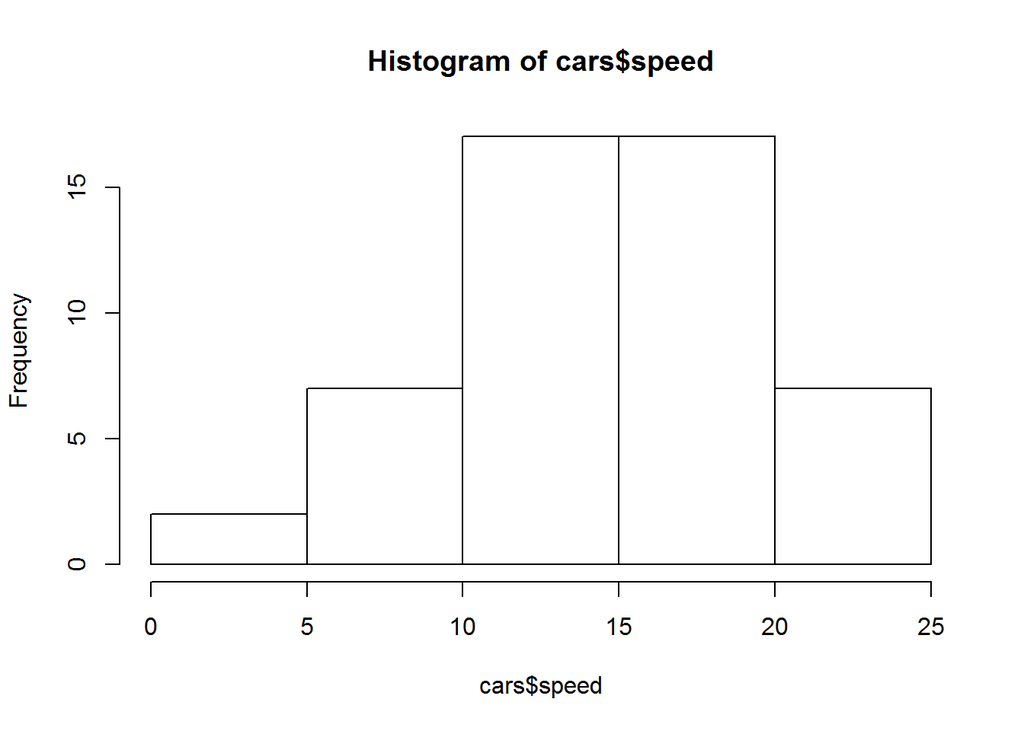

```r
hist(cars$speed)
```

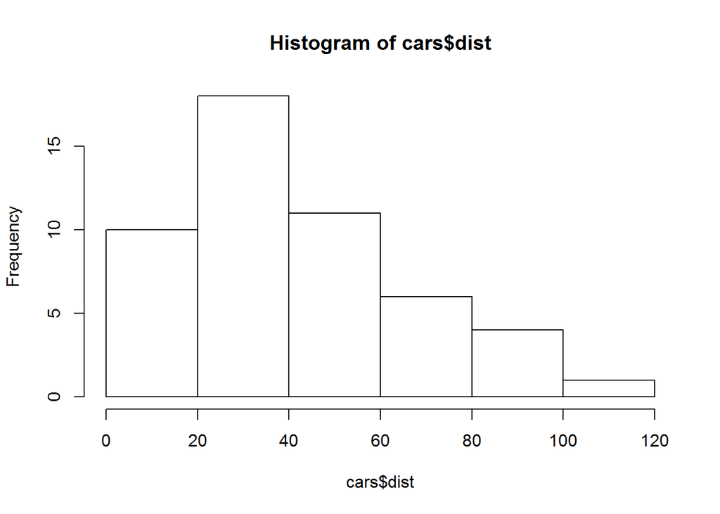

```r
hist(cars$dist)
```

**Find out the outliers in speed and distance variables**

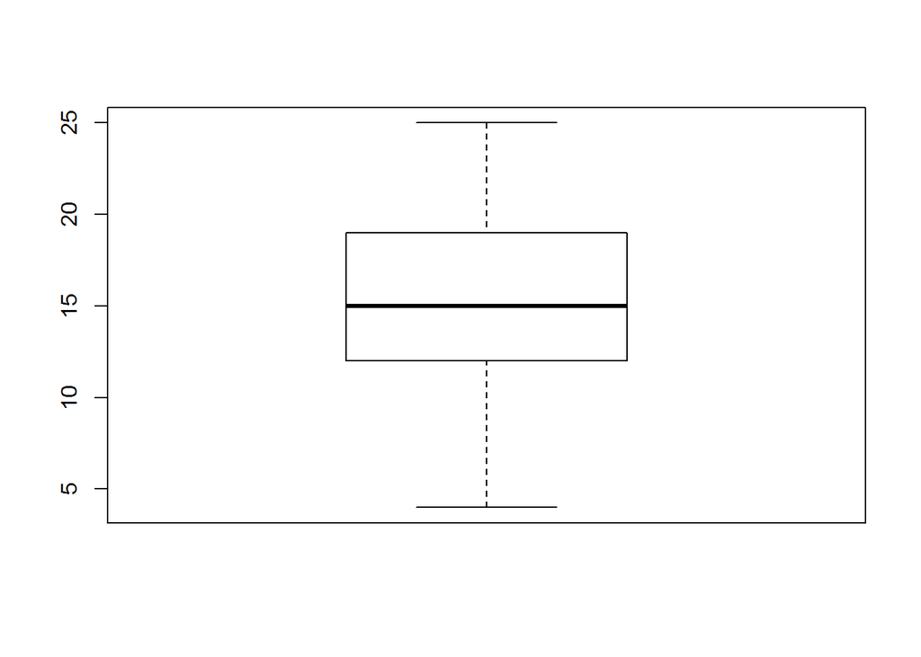

```r
boxplot(cars$speed)
```

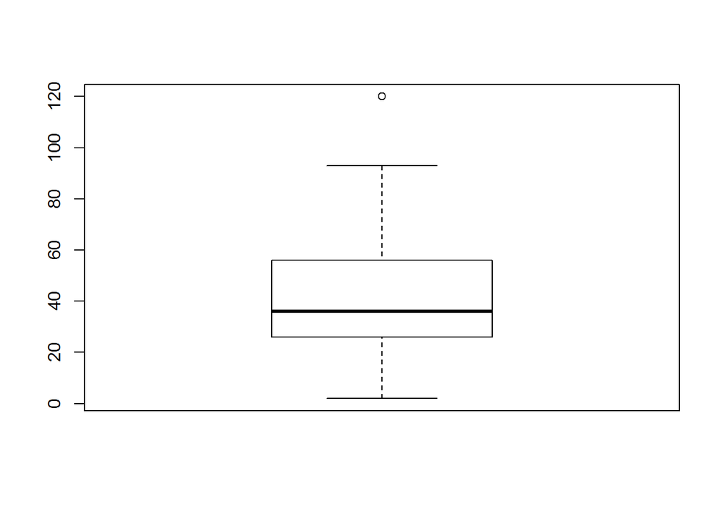

```r
boxplot(cars$dist)
```

**From the above box plots we can see that speed is uniformly distributed without much skew and there are no outliers detected in speed variable.**

**Distance variable indicates right skewed data with one potential outlier**

**Outlier is a point with stopping distance of 120 for speed 24. Let’s replace this outlier with avg stopping distance for speed 24**

```r
cars[cars$dist == max(cars$dist), 'dist'] = mean(cars[cars$speed == 24 & cars$dist != max(cars$dist),'dist'])
```

### Bivariate Analysis

**Let’s see the corrlation between Speed and Distance. Let’s plot a scatter plot**

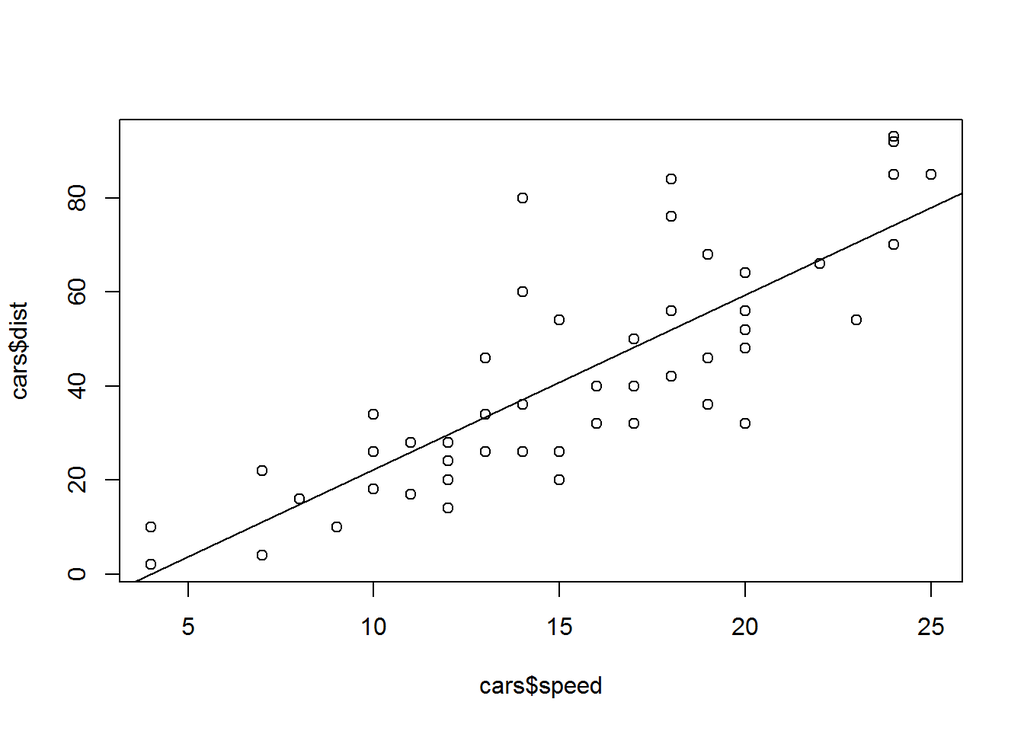

```r
plot(cars$dist ~ cars$speed)
abline(lm(cars$dist ~ cars$speed))
```

**From the above scatter plot we can see that Distance and Speed are positively correlated. The relationship appears to be somewhat linear even though not perfectly linear**

### Model Fitting

**Let’s fit the linear model between speed and distance**

```r
lm.cars.fit = lm(dist~speed, data=cars)
```

### Model summary analysis

**Let’s analize model summary**

```r
summary(lm.cars.fit)
```

```
##
## Call:
## lm(formula = dist ~ speed, data = cars)
##
## Residuals:
##     Min      1Q  Median      3Q     Max
## -27.358  -9.470  -1.370   9.303  42.918
##
## Coefficients:
##             Estimate Std. Error t value Pr(>|t|)
## (Intercept) -14.8956     6.1704  -2.414   0.0196 *
## speed         3.7127     0.3794   9.787 5.11e-13 ***
## ---
## Signif. codes:  0 '***' 0.001 '**' 0.01 '*' 0.05 '.' 0.1 ' ' 1
##
## Residual standard error: 14.04 on 48 degrees of freedom
## Multiple R-squared:  0.6662, Adjusted R-squared:  0.6592
## F-statistic: 95.78 on 1 and 48 DF,  p-value: 5.105e-13
```

**Let’s analyze each component one by one**

**P Values of Intercept and Speed variables are statestically significant. This indicates that both are useful while fitting the model.**

**The Standard error for Intercept and speed variable is small. This indicates that there is less variability in the coefficient estimation of Intercept and speed variable**

**6] F Statistics - F Statistics indicates importance of the feature used in the model cumulatively. Since in our case we have just one feature (speed), we can ignore this statistics.**

### Residual Analysis

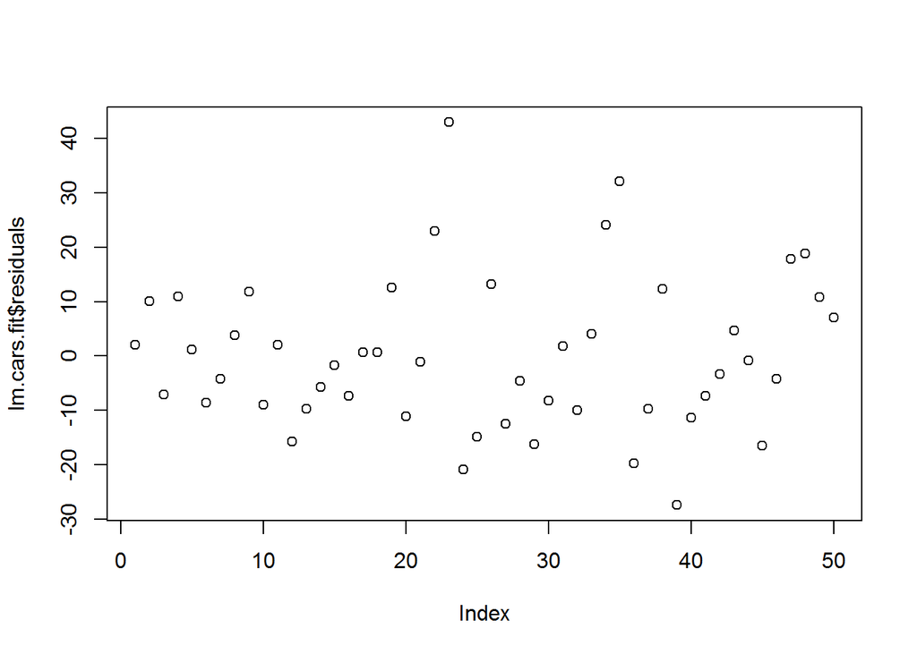

```r
plot(lm.cars.fit$residuals)
```

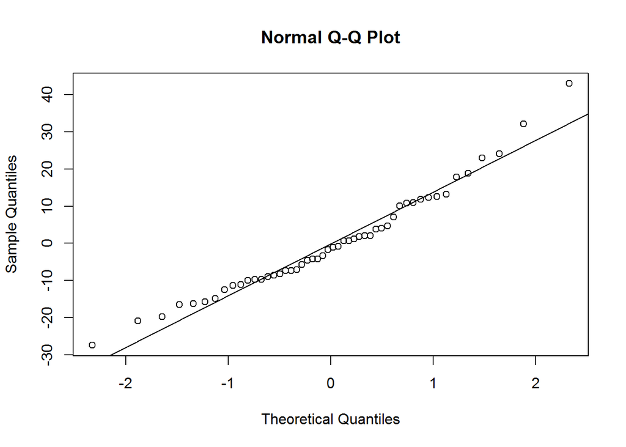

```r
qqnorm(resid(lm.cars.fit))
qqline(resid(lm.cars.fit))
```

** Let’s focus more on Residual Analysis**

**1] Homoscadasticity - From the residual plot above, we can see that residuals are increasing as speed increases. We expect residuls without any pattern as a shapeless cloud. Here we can see that residuals are not homoscadastic**

**2] Y axis Imbalance - Residulas should be balance on Y axis equally centered around 0. From the above plot we can see that residuals are Y axis imbalance**

**3] Nonlinear Pattern - We can see that residuals show little non linear pattern. This indicates that there is not strict linear relationship between speed and distance**

**4] Normal Distribution - From the quantile density plot above we can see that residuals are not normally distributed**

**All above factors indicates speed alone is not a very good predictor of stopping distance. We will have to add more features to increase goodness of fit for our model**